# `Twitter US Airline Sentiment Analysis`

## `Domain:`

Airline

## `Description:`

Modern social media allows users to share their personal views, opinions and experiences. This is a great source of information and it allows us to decide what services we want to use and what to expect from certain companies. It is also especially important to businesses like airline companies in order to stay competitive and potentially use this data to improve the quality of their services.

## `Attributes Information:`

A sentiment analysis job about the problems of each major U.S. airline. Twitter data was scraped from February of 2015 and contributors were asked to first classify positive, negative, and neutral tweets, followed by categorizing negative reasons (such as "late flight" or "rude service").

Link to the Kaggle project site: https://www.kaggle.com/crowdflower/twitter-airline-sentiment

- **tweet_id**: The id of the tweet.
- **airline_sentiment**: Sentiment classification: "neutral", "positive", or "negative".
- **airline_sentiment_confidence**: Sentiment confidence score.
- **negativereason**: If sentiment was negative, the reason categorization: "Late Flight", "Lost Luggage" etc.
- **negativereason_confidence**: Negative reason confedence scrore.
- **airline**: Airline name.
- **name**: User name.
- **retweet_count**: Number of retweets.
- **text**: Tweet content.
- **tweet_created**: Date/Time of the tweet.
- **tweet_coord**: Longitude and latitude of the user location.
- **tweet_location**: Location name.
- **user_timezone**: Location timezone.

## `Objective:`

Analyze how travelers in February 2015 expressed their feelings on Twitter and build a model for sentiment classification using the techniques learnt as a part of the course.

## `Steps and tasks`

1. Libraries & Dataset Import
2. EDA
3. Extract data for pre-processing
4. Text pre-processing. Data preparation.
1. Definning & Testing Pre-processing Functions
2. Building Normalization Function & Testing
3. Cleanining our Data
4. Looking at Sentiment Vocabulary
5. Split into Training & Testing
5. Vectorization
6. Build, Fit and Evaluate Models
7. Summary

## 1. Libraries & Dataset Import

```python
# Basic imports
import pandas as pd
import numpy as np

# Plots
import matplotlib
import matplotlib.pyplot as plt
%matplotlib inline
import seaborn as sns

import warnings
warnings.filterwarnings('ignore')

from IPython.core.display import display
```

```python
from bs4 import BeautifulSoup

import nltk
import contractions
import re
import unicodedata

from nltk.corpus import stopwords
nltk.download('stopwords') # Download stopwords if needed

from nltk.tokenize import word_tokenize
nltk.download('punkt') # Remember word_tokenize() implicitly calls sent_tokenize() which requires punkt package

from nltk.stem import LancasterStemmer

from nltk.stem import WordNetLemmatizer
nltk.download('wordnet') # Download wordnet corpus

from wordcloud import WordCloud
```

```python
from sklearn.feature_extraction.text import CountVectorizer, TfidfVectorizer
```

```python
df = pd.read_csv('Tweets.csv')
df.head()
```

|  | tweet_id | airline_sentiment | airline_sentiment_confidence | negativereason | negativereason_confidence | airline | airline_sentiment_gold | name | negativereason_gold | retweet_count | text | tweet_coord | tweet_created | tweet_location | user_timezone |
| --- | --- | --- | --- | --- | --- | --- | --- | --- | --- | --- | --- | --- | --- | --- | --- |
| 0 | 570306133677760513 | neutral | 1.0000 | NaN | NaN | Virgin America | NaN | cairdin | NaN | 0 | @VirginAmerica What @dhepburn said. | NaN | 2015-02-24 11:35:52 -0800 | NaN | Eastern Time (US & Canada) |
| 1 | 570301130888122368 | positive | 0.3486 | NaN | 0.0000 | Virgin America | NaN | jnardino | NaN | 0 | @VirginAmerica plus you've added commercials t... | NaN | 2015-02-24 11:15:59 -0800 | NaN | Pacific Time (US & Canada) |
| 2 | 570301083672813571 | neutral | 0.6837 | NaN | NaN | Virgin America | NaN | yvonnalynn | NaN | 0 | @VirginAmerica I didn't today... Must mean I n... | NaN | 2015-02-24 11:15:48 -0800 | Lets Play | Central Time (US & Canada) |
| 3 | 570301031407624196 | negative | 1.0000 | Bad Flight | 0.7033 | Virgin America | NaN | jnardino | NaN | 0 | @VirginAmerica it's really aggressive to blast... | NaN | 2015-02-24 11:15:36 -0800 | NaN | Pacific Time (US & Canada) |
| 4 | 570300817074462722 | negative | 1.0000 | Can't Tell | 1.0000 | Virgin America | NaN | jnardino | NaN | 0 | @VirginAmerica and it's a really big bad thing... | NaN | 2015-02-24 11:14:45 -0800 | NaN | Pacific Time (US & Canada) |

```python
df.shape
```

```
(14640, 15)
```

## 2. EDA

Here we will explore our data. First, we start with some aggregative numbers and proceed with some data visualizations.

```python
df.info()
```

```
<class 'pandas.core.frame.DataFrame'>
RangeIndex: 14640 entries, 0 to 14639
Data columns (total 15 columns):
 #   Column                        Non-Null Count  Dtype
---  ------                        --------------  -----
 0   tweet_id                      14640 non-null  int64
 1   airline_sentiment             14640 non-null  object
 2   airline_sentiment_confidence  14640 non-null  float64
 3   negativereason                9178 non-null   object
 4   negativereason_confidence     10522 non-null  float64
 5   airline                       14640 non-null  object
 6   airline_sentiment_gold        40 non-null     object
 7   name                          14640 non-null  object
 8   negativereason_gold           32 non-null     object
 9   retweet_count                 14640 non-null  int64
 10  text                          14640 non-null  object
 11  tweet_coord                   1019 non-null   object
 12  tweet_created                 14640 non-null  object
 13  tweet_location                9907 non-null   object
 14  user_timezone                 9820 non-null   object
dtypes: float64(2), int64(2), object(11)
memory usage: 1.7+ MB
```

```python
df.isnull().sum()
```

```
tweet_id                            0
airline_sentiment                   0
airline_sentiment_confidence        0
negativereason                   5462
negativereason_confidence        4118
airline                             0
airline_sentiment_gold          14600
name                                0
negativereason_gold             14608
retweet_count                       0
text                                0
tweet_coord                     13621
tweet_created                       0
tweet_location                   4733
user_timezone                    4820
dtype: int64
```

```python
df.nunique()
```

```
tweet_id                        14485
airline_sentiment                   3
airline_sentiment_confidence     1023
negativereason                     10
negativereason_confidence        1410
airline                             6
airline_sentiment_gold              3
name                             7701
negativereason_gold                13
retweet_count                      18
text                            14427
tweet_coord                       832
tweet_created                   14247
tweet_location                   3081
user_timezone                      85
dtype: int64
```

```python
duplicate_count = df.duplicated(keep='first').sum()
print(f'Total duplicates: {duplicate_count}')
```

```
Total duplicates: 36
```

We can see that we have only **14485** unique tweet_ids while the total number of the tweets is **14640**. This means some tweets are represented several times in our dataset. Let us see some more details.

```python
tweet_count_df = df.groupby('tweet_id').count()
tweet_count_df = tweet_count_df[tweet_count_df['airline_sentiment'] > 1]
duplicate_tweet_ids = tweet_count_df.reset_index()['tweet_id'].to_numpy()

dup_twet_df = df[df['tweet_id'].isin(duplicate_tweet_ids)].sort_values(by=['tweet_id'])
duplicate_count = dup_twet_df.duplicated(keep='first').sum()

display(dup_twet_df.head(6))
print(f'Number of duplicate tweet ids: {len(duplicate_tweet_ids)}')
print(f'Number of tweets with not unique id: {dup_twet_df.shape[0]}')
print(f'Full duplicates: {duplicate_count}')
```

|  | tweet_id | airline_sentiment | airline_sentiment_confidence | negativereason | negativereason_confidence | airline | airline_sentiment_gold | name | negativereason_gold | retweet_count | text | tweet_coord | tweet_created | tweet_location | user_timezone |
| --- | --- | --- | --- | --- | --- | --- | --- | --- | --- | --- | --- | --- | --- | --- | --- |
| 12033 | 569600137296633856 | positive | 0.9236 | NaN | 0.0000 | American | positive | douglaskgordon | NaN | 0 | @AmericanAir Thank you.....you do the same!! | NaN | 2015-02-22 12:50:30 -0800 | Caribbean, New York and Miami. | Indiana (East) |
| 14556 | 569600137296633856 | positive | 1.0000 | NaN | NaN | American | NaN | douglaskgordon | NaN | 0 | @AmericanAir Thank you.....you do the same!! | NaN | 2015-02-22 12:50:30 -0800 | Caribbean, New York and Miami. | Indiana (East) |
| 14543 | 569601363799359488 | negative | 1.0000 | Flight Attendant Complaints | 1.0000 | American | NaN | stevereasnors | NaN | 0 | @AmericanAir should reconsider #usairways acqu... | NaN | 2015-02-22 12:55:22 -0800 | Los Angeles | Pacific Time (US & Canada) |
| 12032 | 569601363799359488 | negative | 0.9553 | Flight Attendant Complaints | 0.9553 | American | negative | stevereasnors | Flight Attendant Complaints | 0 | @AmericanAir should reconsider #usairways acqu... | NaN | 2015-02-22 12:55:22 -0800 | Los Angeles | Pacific Time (US & Canada) |
| 12031 | 569621879633391616 | negative | 1.0000 | Customer Service Issue | 1.0000 | American | negative | salitron78 | Customer Service Issue | 0 | @AmericanAir no response to DM or email yet. ... | NaN | 2015-02-22 14:16:53 -0800 | on @TheJR | Seoul |
| 14392 | 569621879633391616 | negative | 1.0000 | Customer Service Issue | 1.0000 | American | NaN | salitron78 | NaN | 0 | @AmericanAir no response to DM or email yet. ... | NaN | 2015-02-22 14:16:53 -0800 | on @TheJR | Seoul |

```
Number of duplicate tweet ids: 155
Number of tweets with not unique id: 310
Full duplicates: 36
```

**Insights:**

- We have total of **14640** tweets in the dataset, but only **14485** unique tweets. We only have **7701** unique users which means some users tweeted more than once.
- We can confirm that **airline_sentiment** has only **3** unique values, **negativereason** - **10** and **airline** has **6** company names in total.
- There are many **NULL** values for the most of the columns.
- We found **155** tweet_ids that has 2 entries each, accounting for **310** entries in total. Each pair can have some **difference in sentiment** evaluation, but the **same tweet text**. **36** out of them are full duplicates. This may point to the fact that some tweets were evaluated twice.

Now let us visualize some data.

**Let's see the overall amount of tweets and sentiments.**

```python
sent_palette=['tomato', 'steelblue', 'mediumseagreen', 'khaki', 'plum', 'lightseagreen']
sent_cmap = matplotlib.colors.ListedColormap(sent_palette)

def plot_counts_percentages(data, col, vr=0, pal=sent_palette):
    total_items = data.shape[0]
    chart = sns.countplot(data[col], order = data[col].value_counts().index, palette=pal);
    chart.set(title=col.title(), xlabel='', ylabel='Count')
    chart.set_xticklabels(chart.get_xticklabels(),  rotation=vr)
    for p in chart.patches:
        height = p.get_height()
        chart.text(p.get_x() + p.get_width()/2., height + 4, '{:1.2f}'.format((height/total_items)*100), ha='center')
```

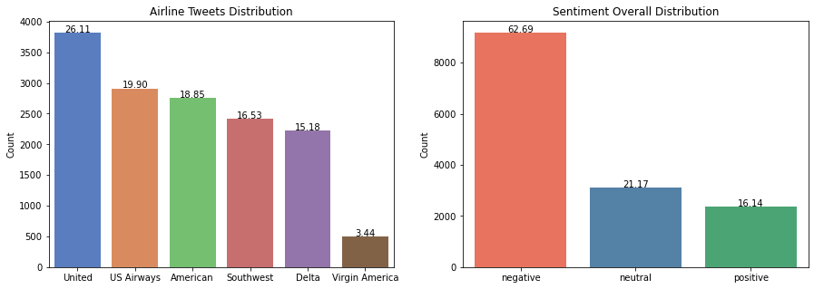

```python
plt.figure(figsize=(15,5))
plt.subplot(1, 2, 1)
plot_counts_percentages(df, 'airline', pal='muted');
plt.title('Airline Tweets Distribution')
plt.subplot(1, 2, 2)
plot_counts_percentages(df, 'airline_sentiment');
plt.title('Sentiment Overall Distribution')
plt.show()
```

**Let us see the distribution of the sentiments across airline companies.**

```python
pd.crosstab(df['airline'], df['airline_sentiment'], margins=True)
```

| airline_sentiment airline | negative | neutral | positive | All |
| --- | --- | --- | --- | --- |
| American | 1960 | 463 | 336 | 2759 |
| Delta | 955 | 723 | 544 | 2222 |
| Southwest | 1186 | 664 | 570 | 2420 |
| US Airways | 2263 | 381 | 269 | 2913 |
| United | 2633 | 697 | 492 | 3822 |
| Virgin America | 181 | 171 | 152 | 504 |
| All | 9178 | 3099 | 2363 | 14640 |

**Let us plot how often airlines are tweeted on and what kind of sentiment they have.**

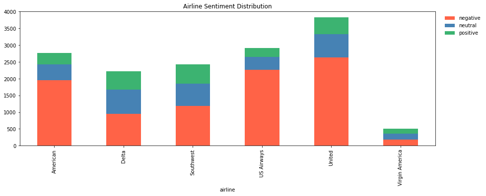

```python
cmap = matplotlib.colors.ListedColormap(['tomato', 'steelblue', 'mediumseagreen'])
airline_sentiment_freq = grp = df.groupby(['airline_sentiment', 'airline']).size().reset_index().pivot(columns='airline_sentiment', index='airline', values=0)
airline_sentiment_freq.plot(figsize=(15, 5), kind='bar', stacked=True, colormap=cmap, title='Airline Sentiment Distribution')
plt.legend(loc='upper right', bbox_to_anchor=(0.12, 0, 1, 1), framealpha=0)
plt.show()
```

**Now let us see the percentage/normalized distribution for each airline.**

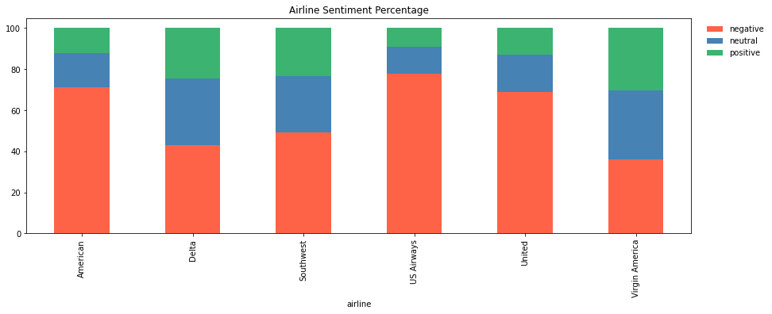

```python
cmap = matplotlib.colors.ListedColormap(['tomato', 'steelblue', 'mediumseagreen'])
airline_sentiment_percent = df.groupby(['airline', 'airline_sentiment']).size().groupby(level=0).apply(lambda x: 100 * x / x.sum()).unstack()
airline_sentiment_percent.plot(figsize=(15, 5), kind='bar', stacked=True, colormap=cmap, title='Airline Sentiment Percentage')
plt.legend(loc='upper right', bbox_to_anchor=(0.12, 0, 1, 1), framealpha=0)
plt.show()
```

**Insights:**

- **United** has the largest number of teweets and **Virgin America** - the smallest.
- The dataset has **~63%** of **negative** tweets with **neutral** and **positive** shearing the rest. Hence we have an **imbalanced dataset**.
- From the percentage plot (normalized) we can see which airline company is better. **Virgin America** for instance, inspite of having not a lot of tweets, has the best count for **positive** responses. **US Airways**, on the other hand, has the largest percent of **negative** tweets.

As we know in case of the **negative** sentiment we also have a more detailed reason. Let us see the distributions.

```python
negative_sentiments = df[df['airline_sentiment'] == 'negative']
negative_sentiments = pd.DataFrame(negative_sentiments[['airline', 'negativereason']])
negative_sentiments.info()
```

```
<class 'pandas.core.frame.DataFrame'>
Int64Index: 9178 entries, 3 to 14638
Data columns (total 2 columns):
 #   Column          Non-Null Count  Dtype
---  ------          --------------  -----
 0   airline         9178 non-null   object
 1   negativereason  9178 non-null   object
dtypes: object(2)
memory usage: 215.1+ KB
```

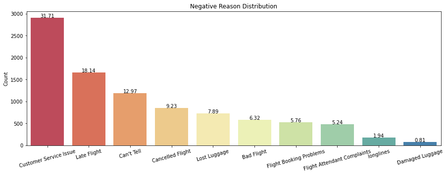

```python
plt.figure(figsize=(15,5))
plot_counts_percentages(negative_sentiments, 'negativereason', vr=15, pal='Spectral');
plt.title('Negative Reason Distribution')
plt.show()
```

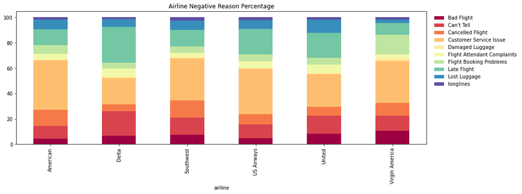

```python
airline_sentiment_percent = negative_sentiments.groupby(['airline', 'negativereason']).size().groupby(level=0).apply(lambda x: 100 * x / x.sum()).unstack()
airline_sentiment_percent.plot(figsize=(15, 5), kind='bar', stacked=True, colormap='Spectral', title='Airline Negative Reason Percentage')
plt.legend(loc='upper right', bbox_to_anchor=(0.23, 0, 1, 1), framealpha=0)
plt.show()
```

**Insights:**

- **Customer Service Issue** is overall the most common reason for the **negative** tweet, following by **Late flight** as the second common reason.
- As we look at the normalized distribution of negative reasons across airline companies we see it varies. Many companies would have **Customer Service Issue** as the top issue, however **Delta** for instance has **Late flight** as the bigget problem.
- Some types of reasons are relatively small across the majority of the airlines, like **Long Lines**, **Lost Luggage** or **Bad Flight**.
- And we can see that **Flight Booking Problems** accounts for relatively big number for **Virgin America** when compared to other players.

## 3. Extract data for pre-processing

For our purposes we will drop all the columns except **airline_sentiment** and **text**.

```python
def display_no_width(data):
    pd.set_option('display.max_colwidth', None)
    display(data)
    pd.set_option('display.max_colwidth', 50)
```

```python
cdf = pd.DataFrame(df[['airline_sentiment', 'text']])
display_no_width(cdf.head())
```

|  | airline_sentiment | text |
| --- | --- | --- |
| 0 | neutral | @VirginAmerica What @dhepburn said. |
| 1 | positive | @VirginAmerica plus you've added commercials to the experience... tacky. |
| 2 | neutral | @VirginAmerica I didn't today... Must mean I need to take another trip! |
| 3 | negative | @VirginAmerica it's really aggressive to blast obnoxious "entertainment" in your guests' faces &amp; they have little recourse |
| 4 | negative | @VirginAmerica and it's a really big bad thing about it |

```python
cdf.shape
```

```
(14640, 2)
```

## 4. Text pre-processing. Data preparation.

### Definning & Testing Pre-processing Functions

As we will need to implement several pre-processing steps and repeat them on the testing dataset, we will create our functions one by one and then form a pipeline function that will incapsulate all of them.

- **Remove HTML tags**

As far as the simple search goes, there is no HTML tags in the tweets in this dataset. However we will implement this step for complitness and because it is a requirement.

```python
def strip_html_tags(text):
    soup = BeautifulSoup(text, "html.parser")
    stripped_text = soup.get_text()
    return stripped_text
```

```python
strip_html_tags('<li id="notebook_tour" title=""><a href="#">A quick tour of the notebook user interface</a></li>')
```

```
'A quick tour of the notebook user interface'
```

- **Remove the numbers**

```python
def remove_numbers(text):
    return re.sub(r'\d+', '', text)
```

```python
remove_numbers('@AmericanAir 767 seconds from touchdown at Madrid airport in April 2013')
```

```
'@AmericanAir  seconds from touchdown at Madrid airport in April '
```

- **Remove non-ASCII / accented characters**

```python
def remove_non_ascii(text):
    return unicodedata.normalize('NFKD', text).encode('ascii', 'ignore').decode('utf-8', 'ignore')
```

```python
remove_non_ascii('@SouthwestAir Plz Sómě Áccěntěd těxt to #AA for ðŸš« the KC â†”ï¸ OKC directs.')
```

```
'@SouthwestAir Plz Some Accented text to #AA for Ys the KC ai  OKC directs.'
```

- **Remove special characters & punctuation**

```python
def remove_special_and_punctuation(text):
    return re.sub(r'[^\w\s]', '', text) # [a-zA-Z0-9_] & [ \t\n\r\f\v]
```

```python
remove_special_and_punctuation('@SouthwestAir (where) are our / pilots? Plane! is here flight says it\'s still on time, but we should of been off the ground 15 minutes ago.')
```

```
'SouthwestAir where are our  pilots Plane is here flight says its still on time but we should of been off the ground 15 minutes ago'
```

- **Convert to lowercase**

```python
def to_lowercase(text):
    return text.lower()
```

```python
to_lowercase('@SouthwestAir DM sent.  Thank you.')
```

```
'@southwestair dm sent.  thank you.'
```

- **Removal of the URLs**

```python
def remove_urls(text):
    return re.sub(r'http\S+', '', text)
```

```python
remove_urls('@VirginAmerica: Got status on another airline? Upgrade test http://t.co/PYalebgkJt')
```

```
'@VirginAmerica: Got status on another airline? Upgrade test '
```

- **Replace contractions**

```python
def replace_contractions(text):
    return contractions.fix(text)
```

```python
replace_contractions('@VirginAmerica  I applied over 2 needn\t, shan, shan\'t weeks ago. Haven\'t heard back and I\'m flying this week #disappointed')
```

```
'@VirginAmerica  I applied over 2 needn\t, shan, shall not weeks ago. have not heard back and I am flying this week #disappointed'
```

- **Remove emails**

```python
def remove_emails(text):
    return re.sub(r'[a-z0-9\.\-+_]+@[a-z0-9\.\-+_]+\.[a-z]+', '', text)
```

```python
remove_emails('@AmericanAir and feel free to email me mikehertz7@gmail.com - don\'t worry, we\'re not going anywhere')
```

```
"@AmericanAir and feel free to email me  - don't worry, we're not going anywhere"
```

- **Remove tagged Twitter entities**

In this excercise we are going to use techniques that do not capture any natural language constructs like nouns or proverbs or verbs. Hence entities like company or user names won't bring us any value for the purpose of sentiment analisys. In the tweets they are marked by **@** symbol and look like **@AmericanAir** **@justynmoro** for example. We will remove them, but we should be careful as **@** symbol may be cleared by our other filtering functions. Hence this step should be taken before them and also we should remove emails first.

```python
def remove_tweeter_entities(text):
    return re.sub(r'@[A-Za-z]+', '', text)
```

```python
remove_tweeter_entities('@AmericanAir @justynmoro I totally agree. Lousy service!')
```

```
'  I totally agree. Lousy service!'
```

- **Remove stop words**

Stop words are a set of commonly used words in a language. Examples of stop words in English are 'a', 'the', 'is', 'are' etc. The rational behind removing the stop words is that we can focus on the important words instead.

In our current approach we will do **contractions** first and then remove the **stopwords**. This means we will transform words like *shouldn't* to *should not* first. And then we will remove words like **should**, however we should remember that words like **no** or **not** are important for sentiment alalysis, so we need to keep them.

Let us compose our custom stopword list.

```python
full_stopword_list = stopwords.words('english')
retain_stopword_list = [ 'no', 'not']

custom_stopwords = list(set(full_stopword_list) - set(retain_stopword_list))
```

```python
def remove_stopwords(words):
    return [word for word in words if word not in custom_stopwords]
```

```python
remove_stopwords(['Test', 'not', 'no', 'should', 'like', 'will', 'is'])
```

```
['Test', 'not', 'no', 'like']
```

- **Tokenization**

```python
def tokenize(text):
    return word_tokenize(text)
```

```python
tokenize('flight home Cancelled   today Any   way we can get another flight to NYC back')
```

```
['flight',
 'home',
 'Cancelled',
 'today',
 'Any',
 'way',
 'we',
 'can',
 'get',
 'another',
 'flight',
 'to',
 'NYC',
 'back']
```

- **Stemming**

Stemming is the process of reducing inflection in words (e.g. running, runs) to their root form (e.g. run). The 'root' in this case may not be a real root word, but just a canonical form of the original word.

```python
def stem_words(words):
    stemmer = LancasterStemmer()
    return [stemmer.stem(word) for word in words]
```

```python
stem_words(tokenize('Stemming is the process of reducing inflection in words running runs'))
```

```
['stem',
 'is',
 'the',
 'process',
 'of',
 'reduc',
 'inflect',
 'in',
 'word',
 'run',
 'run']
```

- **Lemmatization**

Lemmatization is very similar to the stemming, it removes inflections by mapping a word to its root form. The only difference is that lemmatization actually transforms words to the actual root. For example, the word 'better' would map to 'good'. NLTK provides **WordNetLemmatizer** class which is a thin wrapper around the **wordnet corpus**.

```python
def lemmatize_words(words):
    lemmatizer = WordNetLemmatizer()
    return [lemmatizer.lemmatize(word, pos='v') for word in words]
```

```python
lemmatize_words(tokenize('Stemming is the process of reducing inflection in words running runs'))
```

```
['Stemming',
 'be',
 'the',
 'process',
 'of',
 'reduce',
 'inflection',
 'in',
 'word',
 'run',
 'run']
```

### Building Normalization Function & Testing

```python
def normalize_text(text):
    clean_text = strip_html_tags(text)                        # Remove HTML tags (<b>Text</b> -> Text)
    clean_text = to_lowercase(clean_text)                     # Convert to lower case (BOB -> bob)
    clean_text = remove_emails(clean_text)                    # Remove emails (bob@domain.com)
    clean_text = remove_tweeter_entities(clean_text)          # Remove Tweetter entities (@Bob)
    clean_text = remove_urls(clean_text)                      # Remove URLs (http://domain.com/path)
    clean_text = replace_contractions(clean_text)             # Replace contractions (haven't -> have not)
    clean_text = remove_non_ascii(clean_text)                 # Replace contractions (Áccěntěd -> Accented, 'ð' -> '')
    clean_text = remove_special_and_punctuation(clean_text)   # Remove special chars & punctuation (',' -> '')
    clean_text = remove_numbers(clean_text)                   # Remove numbers ('123' -> '')

    return remove_stopwords(tokenize(clean_text))             # Tokenize and Remove stopwords
```

- **Clean text - Test**

```python
cleaned_words_test = normalize_text('<html><b>@AmericanAir This hasn\'t been some (Áccěntěd těxt), need to notice @bob #AA for Big and sMAll. Write to mike99@gmail.com ðŸš« in April 2013. Link http://t.co/PYalebgkJt.</b></html>')

display(np.array(cleaned_words_test))
print(f'Result: {" ".join(cleaned_words_test)}')
```

```
array(['not', 'accented', 'text', 'need', 'notice', 'aa', 'big', 'small',
       'write', 'ys', 'april', 'link'], dtype='<U8')
```

```
Result: not accented text need notice aa big small write ys april link
```

- **Stem text - Test**

```python
stem_cleaned_words_test = stem_words(cleaned_words_test)
display(np.array(stem_cleaned_words_test))
print(f'Result: {" ".join(stem_cleaned_words_test)}')
```

```
array(['not', 'acc', 'text', 'nee', 'not', 'aa', 'big', 'smal', 'writ',
       'ys', 'april', 'link'], dtype='<U5')
```

```
Result: not acc text nee not aa big smal writ ys april link
```

- **Lemmatize text - Test**

```python
lemm_cleaned_words_test = lemmatize_words(cleaned_words_test)
display(np.array(lemm_cleaned_words_test))
print(f'Result: {" ".join(lemm_cleaned_words_test)}')
```

```
array(['not', 'accent', 'text', 'need', 'notice', 'aa', 'big', 'small',
       'write', 'ys', 'april', 'link'], dtype='<U6')
```

```
Result: not accent text need notice aa big small write ys april link
```

**Insights:**

- As we can see we were able to apply all our **cleaning functions** on the input document, **tokenize**, **remove stop words** using our custom list. Finally we tried **Stemming** and **Lemmatization**, the later gave us more human readable output, so let us proceed with **Lemmatization** and prepare our corpus for vectorization.
- Order of how we apply our functions is important.

### Cleanining the Data

Let us print some data before processing:

```python
display_no_width(cdf.head())
```

|  | airline_sentiment | text |
| --- | --- | --- |
| 0 | neutral | @VirginAmerica What @dhepburn said. |
| 1 | positive | @VirginAmerica plus you've added commercials to the experience... tacky. |
| 2 | neutral | @VirginAmerica I didn't today... Must mean I need to take another trip! |
| 3 | negative | @VirginAmerica it's really aggressive to blast obnoxious "entertainment" in your guests' faces &amp; they have little recourse |
| 4 | negative | @VirginAmerica and it's a really big bad thing about it |

No let us clean our corpus and print the results:

```python
cdf_lemm = cdf.copy()
cdf_lemm['text'] = cdf_lemm.apply(lambda row: ' '.join(lemmatize_words(normalize_text(row['text'])) ), axis=1)
display_no_width(cdf_lemm.head())
```

|  | airline_sentiment | text |
| --- | --- | --- |
| 0 | neutral | say |
| 1 | positive | plus add commercials experience tacky |
| 2 | neutral | not today must mean need take another trip |
| 3 | negative | really aggressive blast obnoxious entertainment guests face little recourse |
| 4 | negative | really big bad thing |

### Looking at Sentiment Vocabulary

Now when we have cleaned up the data let us have a look at what our sentiments are comprised of. We will extract the most frequently used words for each **sentiment** type and then based on the **frequency** of a word we plot a **word cloud**, greater the usage, the greater the size of the word in the cloud.

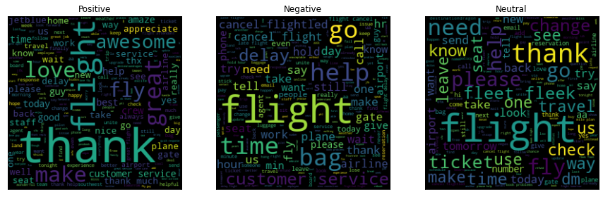

```python
sent_positive = ' '.join(cdf_lemm[cdf_lemm['airline_sentiment'] == 'positive']['text'].to_list())
sent_negative = ' '.join(cdf_lemm[cdf_lemm['airline_sentiment'] == 'negative']['text'].to_list())
sent_neutral = ' '.join(cdf_lemm[cdf_lemm['airline_sentiment'] == 'neutral']['text'].to_list())

sent_positive_cw = WordCloud(width=256, height=256).generate(sent_positive)
sent_negative_cw = WordCloud(width=256, height=256).generate(sent_negative)
sent_neutral_cw = WordCloud(width=256, height=256).generate(sent_neutral)
labels = ['Positive', 'Negative', 'Neutral']

rows = 1
cols = 3
plt.figure(figsize=(15,10))

for index, cw in enumerate([sent_positive_cw, sent_negative_cw, sent_neutral_cw]):
    plt.subplot(rows, cols, index+1)
    plt.xticks([])
    plt.yticks([])
    plt.imshow(cw.to_image(), interpolation='bilinear')
    plt.title(labels[index])

plt.show()
```

**Insights:**

- **Cloud of Words** is a helpful visual representation of the most commonly used words. We can see that for **positive** sentiment we see popular words like **thank, great, awesome, good**, for **negative** - **help, time, cancel, service** and for **neutral** - **need, change, check**.
- There are words common for all types of sentiments, like for instance **flight** or **time**.

### Split into Training & Testing

We will split our data into **trtaining** and **testing** sets now. We do it **before** the **vectorization** step in order to fit the vectorizer only on the **training** set. This approach will adhere more to the reality when the new tweets come in and will allow us to do a better testing of our model.

```python
# Define X and Y variables
X = cdf_lemm['text']
Y = cdf_lemm['airline_sentiment']

# For the target variable we can use LabelEncoder
from sklearn.preprocessing import LabelEncoder
lb_encoder = LabelEncoder()
Y = lb_encoder.fit_transform(Y)
```

```python
from sklearn.model_selection import train_test_split

X_train, X_test, y_train, y_test = train_test_split(X, Y, test_size=0.30, random_state=33)
```

```python
def get_percentage(df, subset):
    return len(subset)/len(df.index) * 100

print('{0:0.2f}% data is in training set'.format(get_percentage(cdf_lemm, X_train)))
print('{0:0.2f}% data is in test set'.format(get_percentage(cdf_lemm, X_test)))
```

```
70.00% data is in training set
30.00% data is in test set
```

## 5. Vectorization

- **CountVectorizer**

**CountVectorizer** converts a collection of text documents to a matrix of token counts. We will keep only **1000 features** as the number of features will not only increase the processing time, but can cause the **Curse of dimensionality**.

```python
cv_vectorizer = CountVectorizer(analyzer='word', tokenizer=None, preprocessor=None, stop_words=None, max_features=1000)

# fit_transform() does two things:
# - First, it fits the model and learns the vocabulary;
# - Second, it transforms our training data into feature vectors.
# The input to fit_transform should be a list of strings.
train_cv_lemm_features = cv_vectorizer.fit_transform(X_train.to_list())
train_cv_lemm_features = train_cv_lemm_features.toarray()
train_cv_lemm_features.shape
```

```
(10248, 1000)
```

```python
test_cv_lemm_features = cv_vectorizer.transform(X_test.to_list())
test_cv_lemm_features = test_cv_lemm_features.toarray()
test_cv_lemm_features.shape
```

```
(4392, 1000)
```

- **TfidfVectorizer**

**TfidfVectorizer** converts a collection of raw documents to a matrix of TF-IDF features. It will give less importance to the most frequent words and also considers less frequent words. We will go with the same assumptions as before and use **1000 features**.

```python
tfidf_vectorizer = TfidfVectorizer(analyzer='word',tokenizer=None, preprocessor=None, stop_words=None, max_features=1000)

train_tfidf_lemm_features = tfidf_vectorizer.fit_transform(X_train.to_list())
train_tfidf_lemm_features = train_tfidf_lemm_features.toarray()
train_tfidf_lemm_features.shape
```

```
(10248, 1000)
```

```python
test_tfidf_lemm_features = tfidf_vectorizer.transform(X_test.to_list())
test_tfidf_lemm_features = test_tfidf_lemm_features.toarray()
test_tfidf_lemm_features.shape
```

```
(4392, 1000)
```

## 6. Build, Fit and Evaluate Models

```python
from sklearn.model_selection import cross_val_score, KFold
from sklearn.metrics import classification_report, confusion_matrix

def evaluate_classifier(classifier, Xtrain, Ytrain, Xtest, Ytest, data):
    classifier.fit(Xtrain, Ytrain)

    training_accuracy = classifier.score(Xtrain, Ytrain)
    testing_accuracy = classifier.score(Xtest, Ytest)

    # Print Report
    print(f'Training accuracy  : {training_accuracy:0.4f}')
    print(f'Testing accuracy   : {testing_accuracy:0.4f}')

    # Confusion Matrix
    y_pred = classifier.predict(Xtest)
    y_test_labels = lb_encoder.inverse_transform(Ytest)
    y_pred_labels = lb_encoder.inverse_transform(y_pred)

    cm = confusion_matrix(Ytest, y_pred)
    print(cm)

    # Plot Confusion Matrix
    labels_list = np.unique(data['airline_sentiment']);
    df_cm = pd.DataFrame(cm, index = [i for i in labels_list], columns = [i for i in labels_list])

    plt.figure(figsize=(5, 5))
    heatmap=sns.heatmap(df_cm, annot=True, cmap='Greens', fmt='d', cbar=False) # mako, YlOrBr, Blues
    heatmap.set_xticklabels(heatmap.get_xticklabels(), rotation=45)
    heatmap.set_yticklabels(heatmap.get_yticklabels(), rotation=0)
    plt.ylabel('Actual')
    plt.xlabel('Predicted')
    plt.show()

    # classification_report
    print(classification_report(y_test_labels, y_pred_labels))
```

```python
from sklearn.model_selection import RandomizedSearchCV
from scipy.stats import randint as sp_randint
seed = 33
```

```python
parameters = {'bootstrap': [True, False],
              'min_samples_split': [2, 3, 5, 10, 15, 20, 30, 50, 70, 100],
              'min_samples_leaf': sp_randint(1, 10),
              'max_depth': [30, 40, 50, 70, 100, 130, 150, 160, 170, 180, 190, 200, None],
              'max_features': [600, 700, 800, 900, 1000],
              'n_estimators': [int(x) for x in np.linspace(start = 30, stop = 300, num = 10)],
              'criterion':['gini', 'entropy']}
```

- **Model based on CountVectorizer**

We will use **RandomForestClassifier** on the output of **CountVectorizer**. Let us use **RandomizedSearchCV** to optimize our hyperparameters.

```python
from sklearn.ensemble import RandomForestClassifier

rforest = RandomForestClassifier(random_state=seed)
rf_rs_cv = RandomizedSearchCV(rforest, n_iter=20, param_distributions=parameters, cv=3)
rf_rs_cv.fit(train_cv_lemm_features, y_train)

print(f'Trainig accuracy: {rf_rs_cv.score(train_cv_lemm_features, y_train):.4f}')
print(f'Testing accuracy: {rf_rs_cv.score(test_cv_lemm_features, y_test):.4f}')
print(f'Mean cross-validated score of the best estimator: {rf_rs_cv.best_score_:.4f}')
print(f'Parameters that gave the best results: {rf_rs_cv.best_params_}')
```

```
Trainig accuracy: 0.8198
Testing accuracy: 0.7621
Mean cross-validated score of the best estimator: 0.7630
Parameters that gave the best results: {'bootstrap': True, 'criterion': 'gini', 'max_depth': 170, 'max_features': 600, 'min_samples_leaf': 2, 'min_samples_split': 100, 'n_estimators': 90}
```

Using our best parameters:

```
Training accuracy  : 0.8198
Testing accuracy   : 0.7621
[[2456  197  100]
 [ 380  458   86]
 [ 185   97  433]]
```

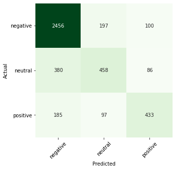

```
              precision    recall  f1-score   support

    negative       0.81      0.89      0.85      2753
     neutral       0.61      0.50      0.55       924
    positive       0.70      0.61      0.65       715

    accuracy                           0.76      4392
   macro avg       0.71      0.66      0.68      4392
weighted avg       0.75      0.76      0.75      4392
```

```python
cv_rf_best = {'random_state':seed, 'bootstrap': True, 'criterion': 'gini', 'max_depth': 170, 'max_features': 600, 'min_samples_leaf': 2, 'min_samples_split': 100, 'n_estimators': 90}

cv_rforest_classifier = RandomForestClassifier(**cv_rf_best)

evaluate_classifier(cv_rforest_classifier, train_cv_lemm_features, y_train, test_cv_lemm_features, y_test, cdf_lemm)
```

- **Model based on TfidfVectorizer**

We will use **RandomForestClassifier** on the output of **TfidfVectorizer**. Let us use **RandomizedSearchCV** to optimize our hyperparameters.

```python
from sklearn.ensemble import RandomForestClassifier

rforest = RandomForestClassifier(random_state=seed)
rf_rs_cv = RandomizedSearchCV(rforest, n_iter=20, param_distributions=parameters, cv=3)
rf_rs_cv.fit(train_tfidf_lemm_features, y_train)

print(f'Trainig accuracy: {rf_rs_cv.score(train_tfidf_lemm_features, y_train):.4f}')
print(f'Testing accuracy: {rf_rs_cv.score(test_tfidf_lemm_features, y_test):.4f}')
print(f'Mean cross-validated score of the best estimator: {rf_rs_cv.best_score_:.4f}')
print(f'Parameters that gave the best results: {rf_rs_cv.best_params_}')
```

```
Trainig accuracy: 0.8728
Testing accuracy: 0.7607
Mean cross-validated score of the best estimator: 0.7654
Parameters that gave the best results: {'bootstrap': True, 'criterion': 'entropy', 'max_depth': 200, 'max_features': 700, 'min_samples_leaf': 2, 'min_samples_split': 30, 'n_estimators': 240}
```

Using our best parameters:

```
Training accuracy  : 0.8441
Testing accuracy   : 0.7564
[[2420  233  100]
 [ 372  467   85]
 [ 176  104  435]]
```

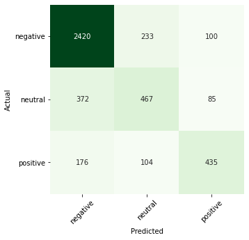

```
              precision    recall  f1-score   support

    negative       0.82      0.88      0.85      2753
     neutral       0.58      0.51      0.54       924
    positive       0.70      0.61      0.65       715

    accuracy                           0.76      4392
   macro avg       0.70      0.66      0.68      4392
weighted avg       0.75      0.76      0.75      4392
```

```python
tfidf_rf_best = {'random_state':seed, 'n_estimators': 120, 'min_samples_split': 50, 'min_samples_leaf': 3, 'max_features': 1000, 'max_depth': 150, 'criterion': 'gini', 'bootstrap': True}

tfidf_rforest_classifier = RandomForestClassifier(**tfidf_rf_best)

evaluate_classifier(tfidf_rforest_classifier, train_tfidf_lemm_features, y_train, test_tfidf_lemm_features, y_test, cdf_lemm)
```

# 7. Summary

After loading and describing data we moved stright forward to our objective of applying our NLP skills for the task of tweet sentimet classification.

**Pre-Processing**

- While working with text it is important to clean it up, remove **"noise"**. For example, for our task of sentiment analysis and classification, it would make no sense to include **HTML tags**. The same would go towards **emails, web site urls, numbers** and other **specific entities** which do not have any sentiment aspect. We have also implemented other common pre-processing techniques such as converitng to **lower case**, replacing/removing **non ASCII** characters, **punctuation** and **contractions**. Finally we removed the **stop words** keeping only those which are **important** for the sentiments, like **"no"** or **"not"**. Also it is important to apply some cleaning functions in a **specific order** to avoid interference.
- After **tokenization** and **stop word** removal we still have an opportunity to reduce the number of dimentions/features by reducing different forms of words to their basic/root form. We implemented both common techniques **Stemming** and **Lemmatization**, but went forward with **Lemmatization** for its natural form of root words. Speed implications did not concerned us here as we don't have a large dataset.

**Vectorization**

- Text is unstructured data and cannot be used as it is. In oreder to convert it into structured form we used **Count** and **Tf-idf** vectorizers. **Count Vectorizer** would just count the frequency of the words in each document for all the documents, giving no special weightage to any of the words. **Tf-idf Vectorizer**, on the other hand, will calculate each word occurrence count and divide it by inverse document matrix. It reduces the impact of words that occur very frequently, hence offering little to none in terms of information. One example of such words will be the word **"flight"**, it is pretty common across all the documents (tweets) in the corpus, but brings no useful information for our task.

**Modeling results**

- We built and tuned two models using **RandomForestClassifier** on our vectorizer's results.
- As we can see both models (based on count & tf-idf vectorizers) give us vertually the same results. However it worth noticing that model based on **tf-idf** inputs tends to overfit more quickly.
- Initial imbalance in the data towards **negative** sentiment biases our models. Looking at our evaluation printed above we can see **precision/recall/f1-score** are all the hihgest for **negative** class. Also **neutrual** and **positive** classes are more often mistaken for **negative**.
- With the current sets of features we can reach testing accuracy in the range of ~**0.74 - 0.78** on both vectorizers. However to get to **0.78** models will overfit significantly going up to **0.99** on the training set. Hence for our best results we chose the parameters that gave us ~**0.75 - 0.76** in accuracy without significat overfitting. **Error Rate** is ~**0.24 - 0.25**.
- One of the most noticable problems though with the current approach is that we are not capturing any sequences. Our model will not understand nouns, verbs, adjectives... no concept of ordering "a b c" or words' relatioship which are inherently important to the natural language processing. Our input data is frequency based and not sequence based.
- Reccomendations on the improvment would be to try **LSTM** model and also work on feature enginering further, for instance we could do the **spell checking** and hence reduce the number of features, or we could have processed **emoji** which would give as a unique insight into the tweets that have them.

Dispite the fact that our model cannot detect **neutral** or **positive** sentiments very well it still can be used to detect majority of **negative** tweets. That on it's own can be a valuable source of information used by airlines for services improvement.